# Predicting exercise patterns

PM

### Objective:

Using devices such as Jawbone Up, Nike FuelBand, and Fitbit it is now possible to collect a large amount of data about personal activity relatively inexpensively. These type of devices are part of the quantified self movement – a group of enthusiasts who take measurements about themselves regularly to improve their health, to find patterns in their behavior, or because they are tech geeks. One thing that people regularly do is quantify how much of a particular activity they do, but they rarely quantify how well they do it. In this project, your goal will be to use data from accelerometers on the belt, forearm, arm, and dumbell of 6 participants. They were asked to perform barbell lifts correctly and incorrectly in 5 different ways. More information is available from the website here: http://groupware.les.inf.puc-rio.br/har (see the section on the Weight Lifting Exercise Dataset).

Loading libraries.

```r
library(randomForest)
```

```r
library(ggplot2)
library(caret)
library(rpart)
library(rattle)
library(reshape2)
library(gbm)
```

Setting multi-core processing.

```r
library(doMC)
registerDoMC(8)
```

Loading data files. These data is provided by (Ugulino et al. 2012).

```r
url_1 <- "https://d396qusza40orc.cloudfront.net/predmachlearn/pml-training.csv"
url_2 <- "https://d396qusza40orc.cloudfront.net/predmachlearn/pml-testing.csv"

file <- download.file(url = url_1, destfile = "trainData.csv", method = "curl")
file <- download.file(url = url_2, destfile = "testData.csv", method = "curl")

train <- read.csv(file = "trainData.csv", na.strings= c('#DIV/0!', '#DIV/0', '', 'NA', ' '))
test <- read.csv(file = "testData.csv", na.strings= c('#DIV/0!','#DIV/0', '', 'NA', ' '))
```

Removing the Na columns and all columns having 60% of Na’s.

```r
train <- train[,colSums(is.na(train)) <nrow(train)*0.6]
test <- test[,colSums(is.na(test)) <nrow(test)*0.6]



train <- train[,-(1:8)]
test <- test[,-(1:8)]
```

Partitioning training in two data sets for validation.

```r
inTrain <- createDataPartition(train$classe, p = 3/4)[[1]]
train.training <- train[ inTrain,]
train.testing <- train[-inTrain,]
```

# Training algorithms

Get the decision tree from recursive partitioning and regression trees.

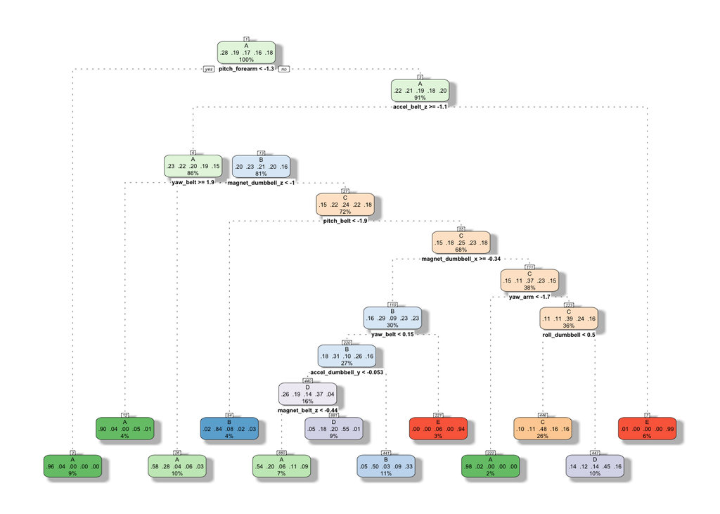

```r
set.seed(13579)
model <- train(classe ~ ., data = train.training, method = "rpart", preProcess=c("center", "scale"))
fancyRpartPlot(model$finalModel, sub = "")
```

Random forest with 5 cross-validations and pre-processing treatment.

```r
set.seed(13579)
model_1 <- train(classe ~ ., data = train.training, method = "rf",
                 preProcess=c("center", "scale"),
                 trControl = trainControl(method="cv", number= 5))

fit_1 <- predict(model_1, train.testing)

conf_1 <- confusionMatrix(fit_1, train.testing$classe)
```

Extracting the prediction vs reference data to create a heat-plot.

[figure not shown]

```r
ttable_1 <- conf_1$table
ttable_1 <- melt(ttable_1)

ggplot(data = ttable_1, aes(x=Prediction, y=Reference,
                            title='Recursive partitioning and regression trees',
                            fill=value)) + geom_tile() + scale_fill_gradient(low="orange", high="darkred") +
        annotate("text",  x = 1.8, y = 5.2,
                 label = paste("accuracy=",round(conf_1$overall[[1]]*100,3), "%"),
                 colour='white')
```

Generalized Boosted Regression Modelling.

```r
set.seed(13579)
model_2 <- train(classe ~ ., data = train.training, method = "gbm", verbose=FALSE, preProcess=c("center", "scale"),
                 trControl = trainControl(method="repeatedcv", number=5, repeats=2),  metric="Accuracy")
fit_2 <- predict(model_2, train.testing)

conf_2 <- confusionMatrix(fit_2, train.testing$classe)
```

Extracting the prediction vs reference data to create a heat-plot.

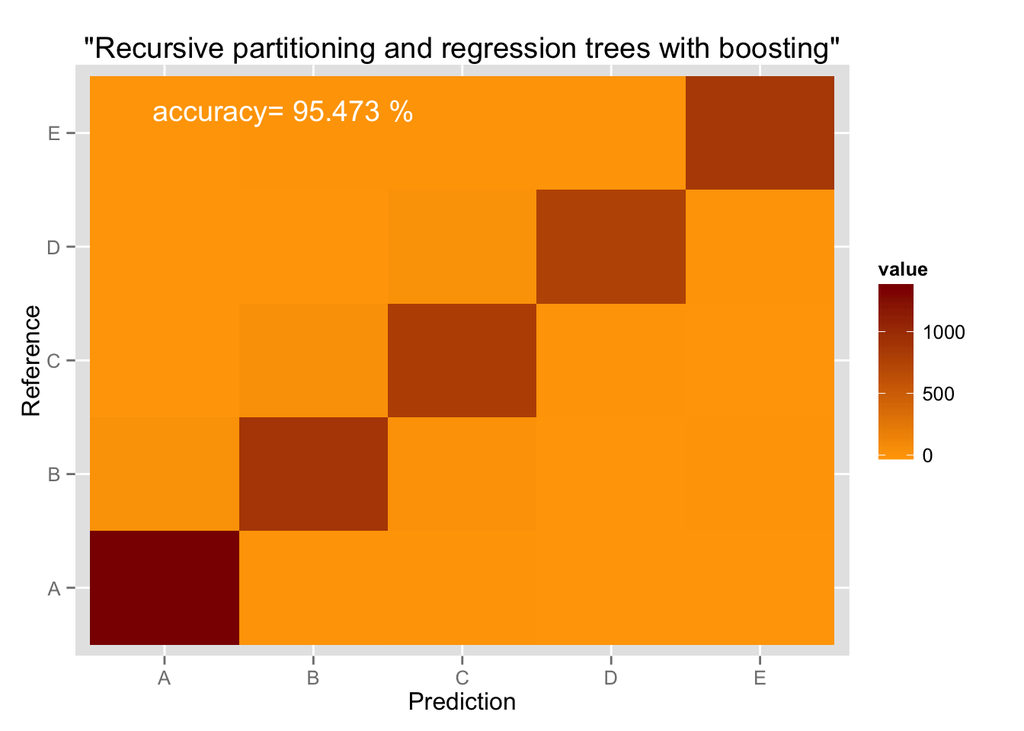

```r
ttable_2 <- conf_2$table
ttable_2 <- melt(ttable_2)

ggplot(data = ttable_2, aes(x=Prediction, y=Reference,
                            title='Recursive partitioning and regression trees with boosting',
                            fill=value)) + geom_tile() + scale_fill_gradient(low="orange", high="darkred") +
        annotate("text",  x = 1.8, y = 5.2,
                 label = paste("accuracy=",round(conf_2$overall[[1]]*100,3), "%"),
                 colour='white')
```

The random forest is giving a higher accuracy than Generalized Boosted Regression Modeling (gmb).

# Predicting

```r
predict(model_1, test)
```

```
##  [1] B A B A A E D B A A B C B A E E A B B B
## Levels: A B C D E
```

```r
answers <- c('B', 'A', 'B', 'A', 'A', 'E', 'D', 'B', 'A', 'A', 'B',
'C', 'B', 'A', 'E', 'E', 'A', 'B', 'B', 'B')
pml_write_files = function(x){
    n = length(x)
    for(i in 1:n){
        filename = paste0("problem_id_",i,".txt")
        write.table(x[i],file=filename,quote=FALSE,row.names=FALSE,col.names=FALSE)
        }
}
pml_write_files(answers)
```

References:

Ugulino, Wallace, Débora Cardador, Katia Vega, Eduardo Velloso, Ruy Milidiú, and Hugo Fuks. 2012. “Wearable Computing: Accelerometers’ Data Classification of Body Postures and Movements.” In *Advances in Artificial Intelligence - SBIA 2012*, 52–61. Springer Science $+$ Business Media. doi:10.1007/978-3-642-34459-6_6.